# RNA-seq analysis

### 2.3. Annotation of the peaks for genomic features

```r
peakAnno_ESR1 <- annotatePeak("~/Bioinfo_Network/training-requirements/ChIP-Seq Analysis/ESR1.bed", tssRegion=c(-3000, 3000),
                         TxDb=txdb, annoDb="org.Hs.eg.db")
```

```
## >> loading peak file...               2022-06-29 02:45:18 PM
## >> preparing features information...      2022-06-29 02:45:18 PM
## >> identifying nearest features...        2022-06-29 02:45:19 PM
## >> calculating distance from peak to TSS...   2022-06-29 02:45:20 PM
## >> assigning genomic annotation...        2022-06-29 02:45:20 PM
## >> adding gene annotation...          2022-06-29 02:45:50 PM
```

```
## >> assigning chromosome lengths           2022-06-29 02:45:50 PM
## >> done...                    2022-06-29 02:45:50 PM
```

```r
peakAnno_FOXA1 <- annotatePeak("~/Bioinfo_Network/training-requirements/ChIP-Seq Analysis/FOXA1.bed", tssRegion=c(-3000, 3000),
                         TxDb=txdb, annoDb="org.Hs.eg.db")
```

```
## >> loading peak file...               2022-06-29 02:45:50 PM
## >> preparing features information...      2022-06-29 02:45:50 PM
## >> identifying nearest features...        2022-06-29 02:45:50 PM
## >> calculating distance from peak to TSS...   2022-06-29 02:45:52 PM
## >> assigning genomic annotation...        2022-06-29 02:45:52 PM
## >> adding gene annotation...          2022-06-29 02:45:57 PM
```

```
## >> assigning chromosome lengths           2022-06-29 02:45:57 PM
## >> done...                    2022-06-29 02:45:57 PM
```

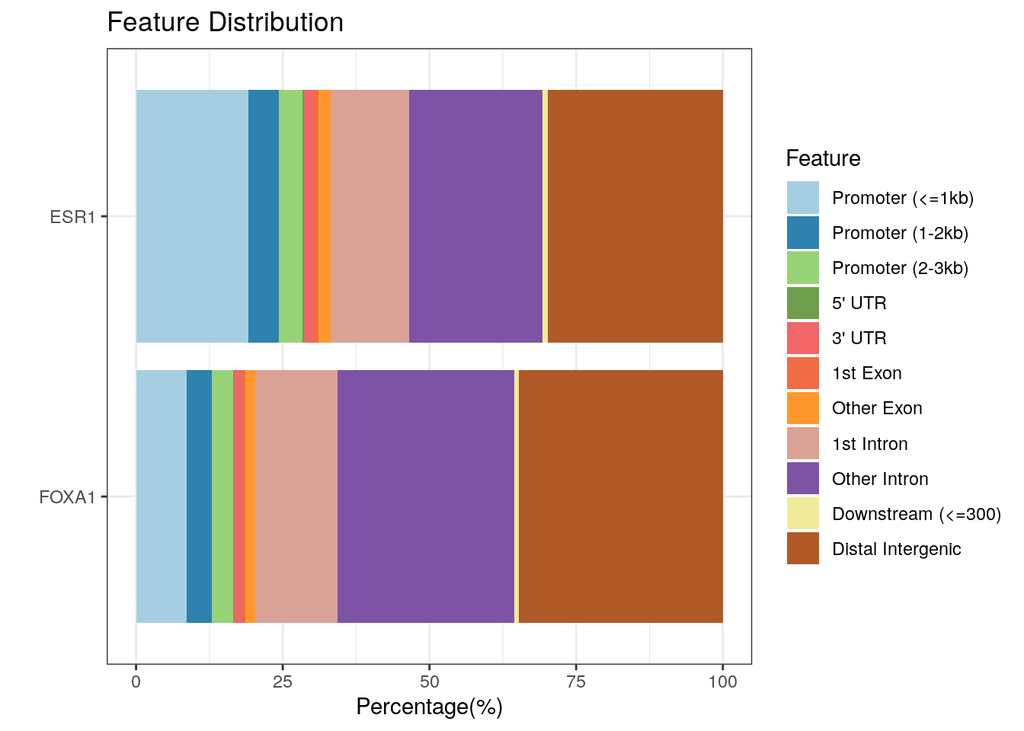

```r
peak_anno_list <- list(peakAnno_ESR1, peakAnno_FOXA1)
names(peak_anno_list) <- c("ESR1", "FOXA1")

plotAnnoBar(peak_anno_list)
```

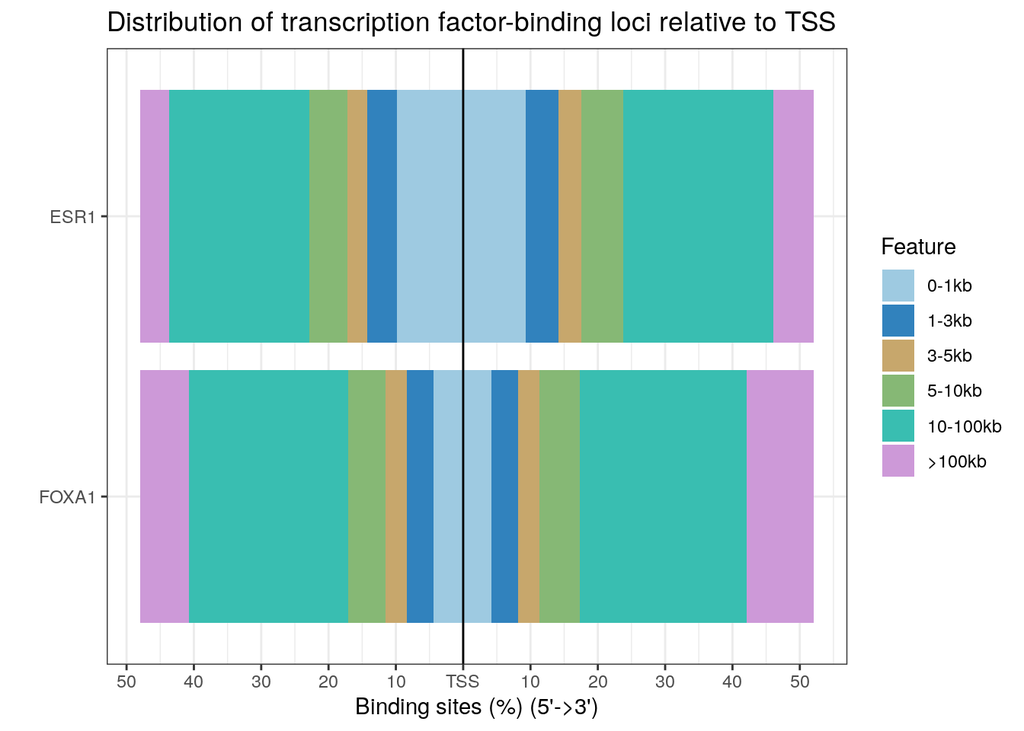

```r
plotDistToTSS(peak_anno_list)
```

Again here we can confirm that ESR1 binds typically more often close to the promoter and the TSS than FOXA1. FOXA1 binds more often to intronic regions or distal intergenic regions than ESR1.

### 2.4. Pathway enrichment

```
## wrong orderBy parameter; set to default `orderBy = "x"`
```

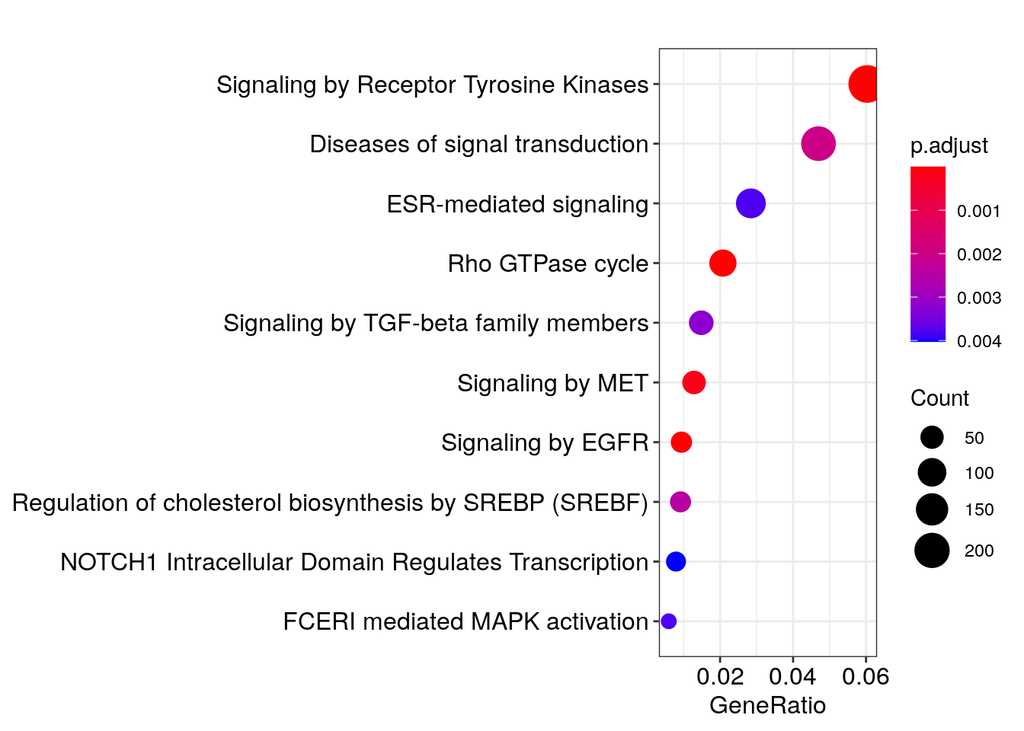

```r
pathway_ESR1 <- enrichPathway(as.data.frame(peakAnno_ESR1)$geneId)
dotplot(pathway_ESR1)
```

```
## wrong orderBy parameter; set to default `orderBy = "x"`
```

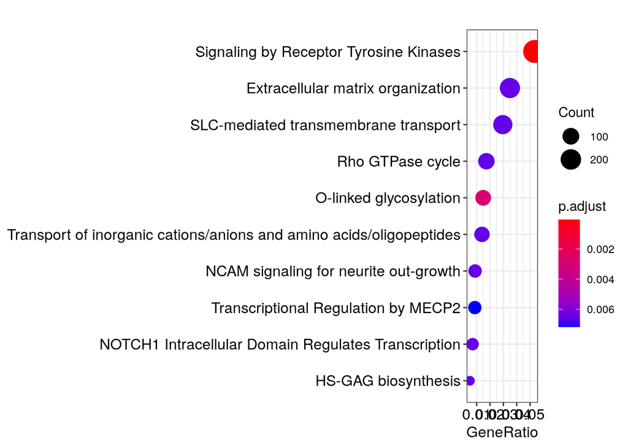

```r
pathway_FOXA1 <- enrichPathway(as.data.frame(peakAnno_FOXA1)$geneId)
dotplot(pathway_FOXA1)
```

Both transcription factors regulate genes involved in similar pathways, like “signaling by receptor of tyrosine kinases”, “Rho GTPs cycle” or “NOTCH1 regulated transcription”.

## 3. Biological interpretation

Both transcription factors that we are analysing here respond to estrogen although they act in a different way. Whereas FOXA1 is a “pioneer” factor that opens up the chromatin, ESR1 promotes the transcription of target genes. The significant amount of overlapping binding sites that we have identified suggests that in some cases both transcription factors act as a team, with FOXA1 binding first and loosening the chromatin and ESR1 coming second to promote gene expression, and this seems to be supported by previous studies (Theodorou et al., 2012). Therefore, it is not surprising that both transcription factors are involved in regulating genes linked to the same pathways, like “signaling by receptor of tyrosine kinases” or “Rho GTPs cycle” for which there is also previous evidence in the literature (Cavalcanti et al., 2015; Tolias et al., 1995).

## 4. References

- Cavalcanti FN, Lucas TF, Lazari MF, Porto CS. Estrogen receptor ESR1 mediates activation of ERK1/2, CREB, and ELK1 in the corpus of the epididymis. J Mol Endocrinol. 2015 Jun;54(3):339-49. doi: 10.1530/JME-15-0086. PMID: 26069273.
- Theodorou V, Stark R, Menon S, Carroll JS. GATA3 acts upstream of FOXA1 in mediating ESR1 binding by shaping enhancer accessibility. Genome Res. 2013 Jan;23(1):12-22. doi: 10.1101/gr.139469.112. Epub 2012 Nov 21. PMID: 23172872; PMCID: PMC3530671.
- Tolias KF, Cantley LC, Carpenter CL. Rho family GTPases bind to phosphoinositide kinases. J Biol Chem. 1995 Jul 28;270(30):17656-9. doi: 10.1074/jbc.270.30.17656. PMID: 7629060.